# Valeurs Extrêmes

Marlène Chevalier

02 février 2020

# Sujet : meilleurs temps à l’épreuve du 100 mètres

Nous avons enregistré les meilleurs temps personnels des coureurs les plus rapides à l’épreuve du 100 mètres entre le 1er janvier 1991 et le 1er avril 2017. Pour exclure, autant que possible, les temps liés au dopage, la période d’observation commence début 1991 (développement des contrôles anti-dopage).  
Chaque athlète n’apparaît qu’une fois dans le jeu de données : l’inclusion de plusieurs performances d’un même athlète ne serait pas conforme à l’hypothèse de données indépendantes. Seuls les temps oﬃciellement reconnus et les temps obtenus avec une vitesse du vent inférieure ou égale à 2m/s sont pris en compte. Les temps pour le 100m sont disponibles en centièmes de secondes.

**source** : *temps100m.csv* qui rassemble

- Pour la période antérieure à 2001, les données proviennant du site Web suédois http://hem.bredband.net/athletics/athleticsall-timebest.htm. Ce site Web fournit les meilleurs temps jusqu’en 2001.
- Pour la période du 01/01/2001 au 01/04/2017, les listes des temps officiels du site Web de l’IAAF : www.iaaf.org.

**Objectif :** Il s’agit de déterminer à quelle vitesse nous sommes capables de courir. Autrement dit, nous nous intéressons au record mondial ultime.

Il s’agit donc d’étudier les valeurs extrêmes de cette série en utilisant et comparant deux approches :

- Generalized Extreme Value (GEV) : distribution géneralisée des valeurs extrêmes
- Generalized Pareto Distribution (GPD) : distribution generalisée de Pareto

# Description de la série

Le jeu de données ne contient qu’une variable (*temps*) qui recense 1005 relevés des meilleurs temps à la course du 100m : ils sont entre 9.58 secondes et 10.30 secondes. La moyenne et la médiane de ces temps sont proches et élévées par rapport à la plage de valeurs, respectivement à 10.16s et 10.2s. Ici on s’intéresse à la variable *temps* pour ses petites valeurs, donc les valeurs extrêmes seront des minima et la queue de distribution de la série représentera les temps les plus bas (cf.histogramme).

```
##      temps
##  Min.   : 9.58
##  1st Qu.:10.07
##  Median :10.20
##  Mean   :10.16
##  3rd Qu.:10.26
##  Max.   :10.30
```

```
##    Min. 1st Qu.  Median    Mean 3rd Qu.    Max.
##    9.58   10.07   10.20   10.16   10.26   10.30
```

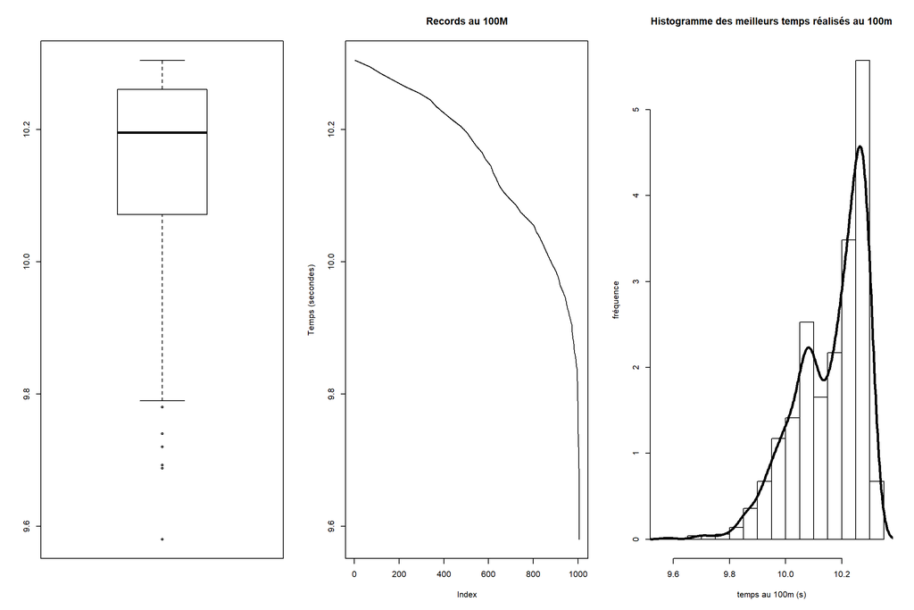

Pour continuer à raisonner avec des maxima, nous ramenons le temps de course au 100m (variable *temps*) au nombre de kilomètres courus en 1 heure (variable *Speed* ).  
Speed=360/temps  
La variable *Speed* prend ses valeurs entre 34.93 et 37.58. La médiane et la moyenne, respectivement de 35.31 et 35.45, sont proches de la valeur minimum observée, ce qui écrasse la série (concentration des performances vers les valeurs basses). Les performances de 8 athlètes se dégagent des autres, dépassant les 36.7km/h au 100m.

```
##    Min. 1st Qu.  Median    Mean 3rd Qu.    Max.
##   34.93   35.08   35.31   35.45   35.74   37.58
```

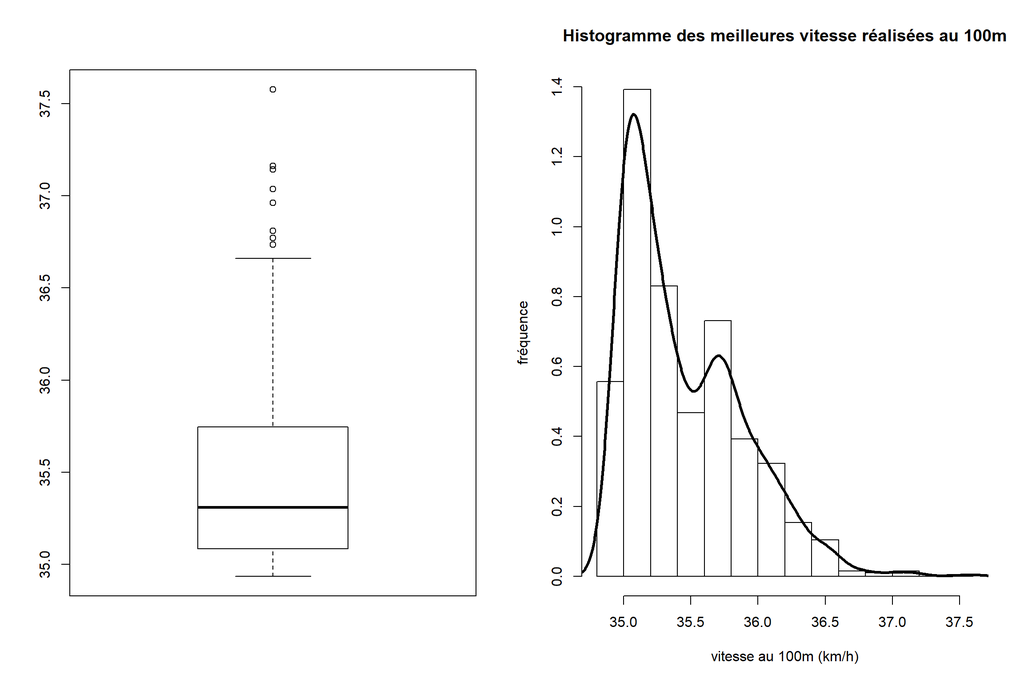

# Modélisation Generalized Extreme Value (GEV) : loi des maxima de la série

Comme la série est constituée des meilleurs temps personnels (assimilables à des maxima), il n’est pas nécessaire de faire d’extraction des maxima par bloc. Nous pouvons donc lancer la modélisation des GEV sur la série brute.

## Modèle GEV avec maximum de vraissemblance (MLE)

```
##
## fevd(x = Speed, type = "GEV", method = "MLE")
##
## [1] "Estimation Method used: MLE"
##
##
##  Negative Log-Likelihood Value:  433.5695
##
##
##  Estimated parameters:
##   location      scale      shape
## 35.1959713  0.2598022  0.3631554
##
##  Standard Error Estimates:
##   location      scale      shape
## 0.01081291 0.00956951 0.04797811
##
##  Estimated parameter covariance matrix.
##               location         scale         shape
## location  1.169189e-04  7.848022e-05 -0.0002798268
## scale     7.848022e-05  9.157552e-05 -0.0001722032
## shape    -2.798268e-04 -1.722032e-04  0.0023018991
##
##  AIC = 873.139
##
##  BIC = 887.8772
```

```
## fevd(x = Speed, type = "GEV", method = "MLE")
##
## [1] "Normal Approx."
##
##          95% lower CI   Estimate 95% upper CI
## location   35.1747784 35.1959713   35.2171642
## scale       0.2410463  0.2598022    0.2785581
## shape       0.2691200  0.3631554    0.4571908
```

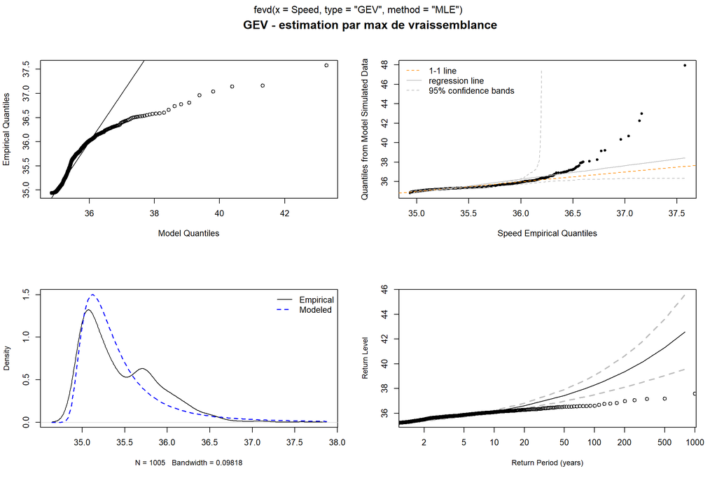

```
## fevd(x = Speed, type = "GEV", method = "MLE")
##
## [1] "Normal Approx."
##
## [1] "100-year return level: 38.283"
##
## [1] "95% Confidence Interval: (37.5011, 39.065)"
```

```
## fevd(x = Speed, type = "GEV", method = "MLE")
##
## [1] "Normal Approx."
##
## [1] "1000-year return level: 43.27"
##
## [1] "95% Confidence Interval: (39.8366, 46.7024)"
```

**Domaine d’attraction des valeurs extrêmes**

La valeur estimée de gamma (shape) est de 0.36 > 0 (avec un intervalle de confiance aux bornes positives). Elle caractérise le domaine d’attraction de Fréchet. Les graphiques montrent un ajustement non convainquant de la loi des extrêmes au DMA de Fréchet : les points empiriques et les courbes représentant le modèle sont éloignés pour des vitesses supérieures à 36km/h.

**Niveaux de retour à 100 ans et 1000 ans**

Le niveau de retour à 100 ans est ici de 38.28 km/h, (9.4 secondes au 100m) et le niveau de retour à 1000 ans de 43.27 km/h,(8.32 secondes au 100m).

## Modèle GEV avec méthode des moments (PWM)

Ici, les coefficients du modèle GEV (position, échelle, forme) sont estimés par la méthode des moments.

```
## fevd(x = Speed, type = "GEV", method = "Lmoments")
## [1] "GEV  Fitted to  Speed  using L-moments estimation."
##    location       scale       shape
## 35.23740211  0.31719369  0.08011575
```

```
## fevd(x = Speed, type = "GEV", method = "Lmoments")
##
## [1] "Parametric Bootstrap"
## 502  iterations
##
##                 2.5%    Estimate      97.5%
## location 35.21443197 35.23740211 35.2615232
## scale     0.30123297  0.31719369  0.3355631
## shape     0.03046374  0.08011575  0.1327403
```

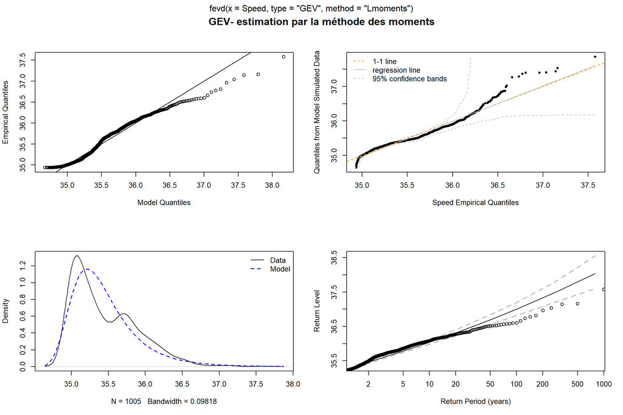

```
## fevd(x = Speed, type = "GEV", method = "Lmoments")
##
## [1] "Parametric Bootstrap"
## 502  iterations
##
## [1] "100-year level: 37.002"
##
## [1] "95% Confidence Interval: (36.8258, 37.211)"
```

```
## fevd(x = Speed, type = "GEV", method = "Lmoments")
##
## [1] "Parametric Bootstrap"
## 502  iterations
##
## [1] "1000-year level: 38.164"
##
## [1] "95% Confidence Interval: (37.678, 38.7263)"
```

**Domaine d’attraction des valeurs extrêmes**

La valeur estimée de gamma (shape=0.0801) et son intervalle de confiance sont là aussi positifs. L’appartenance de la loi des maxima au domaine de Fréchet est confirmée. Les 2 graphiques qqplot(quantiles du modèle / quantiles empiriques et quantiles empiriques/quantiles simulés) ) sont bons jusqu’à 36,5km/h puis, au delà les quantiles empiriques sont surestimés.

**Niveaux de retour à 100 ans et 1000 ans**

Le niveau de retour à 100 ans est ici de 37 km/h, (9.73 secondes au 100m) et le niveau de retour à 1000 ans de 38.16 km/h, (9.43 secondes au 100m).

# Modélisation Generalized Pareto Distribution (GPD) : loi des excès de la série

Il s’agit ici d’envisager les valeurs extrêmes comme les valeurs dépassant un seuil à fixer et donc de modéliser ces dépassements (excès).

## Choix du seuil

**Etude graphique par MRL plot**

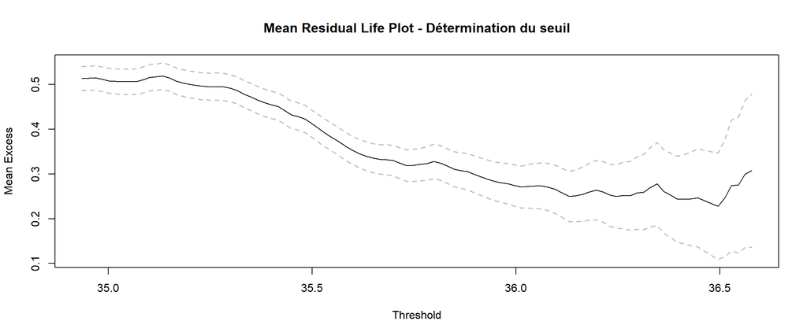

Le graphique “Mean Residual Life Plot” permet d’évaluer une valeur de seuil de la distribution de Pareto (loi des excès). Ce seuil est identifié par une rupture de “linéarité” de la courbe. On observe ici ce changement de comportement autour du niveau de 36.5.km/h

**Seuils en fonction du nombre de dépassements**

Une autre méthode pour évaluer et sélectionner le seuil est de tester plusieurs valeurs en fonction du nombre de dépassements observés au delà de celui-ci (fonction *findThreshold*) . Voici les seuils pour 4 niveaux de dépassements (ici nombre de coureurs ayant atteint ou dépassé le temps-seuil) :

```
##      n=1      n=8     n=20    n=100
## 37.16129 36.65988 36.50190 36.06239
```

Sélectionner un seuil qui définit autour de 1%-2% de valeurs extrêmes peut être un choix raisonnable. On pourrait retenir 36.50 km/h ou 36.66 km/h.

**Seuils en fonction de la stabilité des estimateurs**

Traçons le graphique des valeurs des paramètres en fonction des seuils, afin d’observer graphiquement le comportement des paramètres et en particulier leur stabilité. fonction *threshrange.plot*

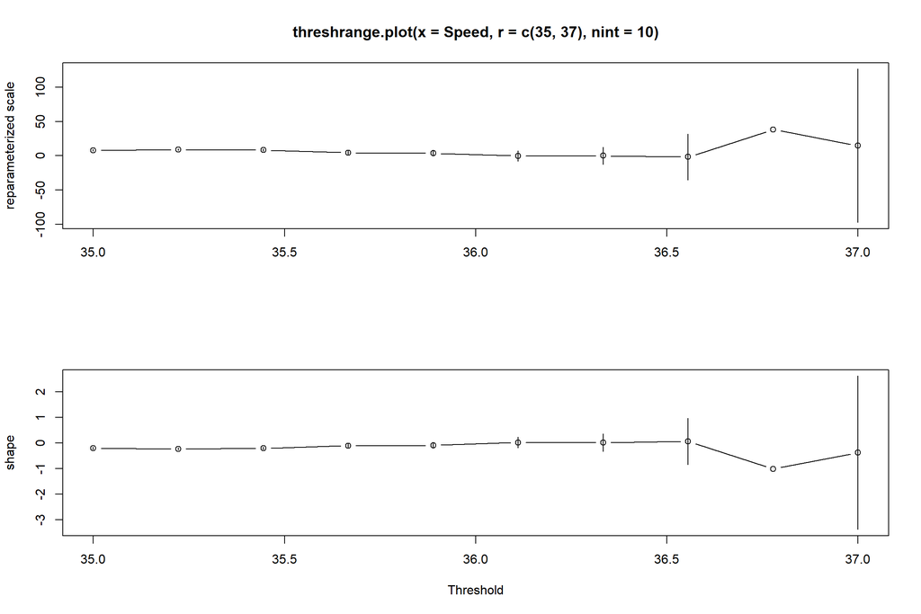

Il apparait sur ces 2 graphiques, une rupture de stabilité des paramètres après 36.5km/h. Choisissons cette valeur pour seuil.

## Modèle GPD avec MLE

A partir d’un seuil fixé, les coefficients du modèle GDP (échelle, forme) sont estimés par maximum de vraissemblance.

```
##
## fevd(x = Speed, threshold = seuil, type = "GP", method = "MLE")
##
## [1] "Estimation Method used: MLE"
##
##
##  Negative Log-Likelihood Value:  -10.39652
##
##
##  Estimated parameters:
##     scale     shape
## 0.1395218 0.4744624
##
##  Standard Error Estimates:
##      scale      shape
## 0.06483582 0.42319470
##
##  Estimated parameter covariance matrix.
##              scale       shape
## scale  0.004203684 -0.02033719
## shape -0.020337193  0.17909375
##
##  AIC = -16.79304
##
##  BIC = -14.70399
```

```
## fevd(x = Speed, threshold = seuil, type = "GP", method = "MLE")
##
## [1] "Normal Approx."
##
##       95% lower CI  Estimate 95% upper CI
## scale   0.01244592 0.1395218    0.2665977
## shape  -0.35498399 0.4744624    1.3039087
```

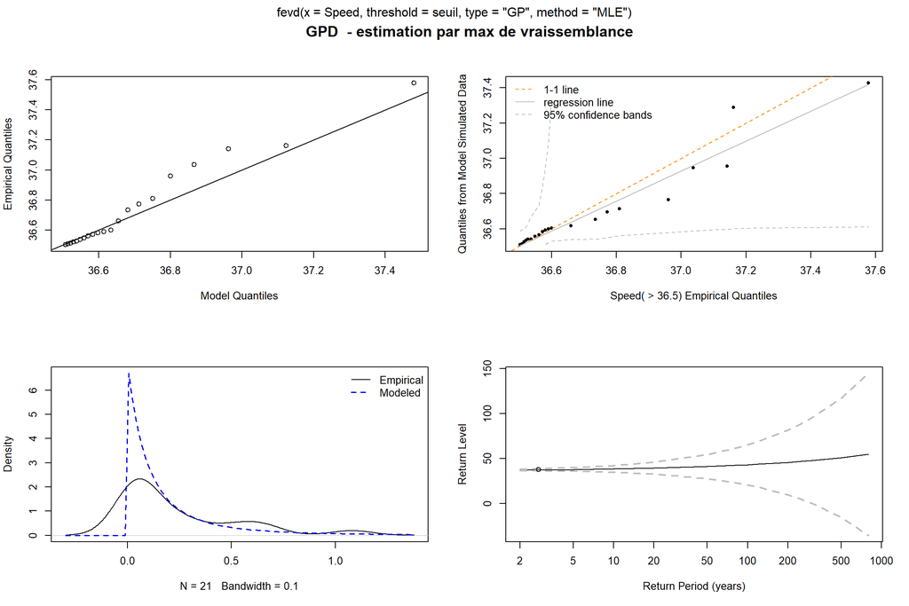

```
## fevd(x = Speed, threshold = seuil, type = "GP", method = "MLE")
##
## [1] "Normal Approx."
##
## [1] "100-year return level: 43.063"
##
## [1] "95% Confidence Interval: (20.8498, 65.2765)"
```

```
## fevd(x = Speed, threshold = seuil, type = "GP", method = "MLE")
##
## [1] "Normal Approx."
##
## [1] "1000-year return level: 56.652"
##
## [1] "95% Confidence Interval: (-46.8647, 160.1686)"
```

```
## scale
## 36.21
```

**Domaine d’attraction**

La valeur estimée de gamma (shape) est de 0.47> 0 . Elle caractérise le domaine d’attraction de Fréchet. Cependant l’intervalle de confiance du paramètre gamma nous indique qu’il pourrait être négatif (borne inférieure du CI <0). Nous testerons ci-après, le résultat de la modélisation pour gamma = 0 (domaine de Gumbel).  
Les graphiques ne donnent pas de bons resultats d’ajustement.

**Niveaux de retour**

Le niveau de retour à 100 ans est ici de 43.06 km/h, (8.36 secondes au 100m) et le niveau de retour à 1000 ans de 56.65 km/h, (6.35 secondes au 100m).

## Modèle GPD Gumbel avec MLE

Testons l’hypothèse de nullité du paramètre de forme, à savoir la distribution Gumbel des excès.

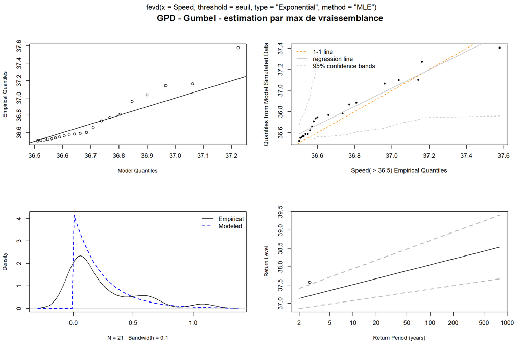

Ici les graphiques d’ajustement donnent de moins bons résultats qu’avec les modélisations précédentes. Nous ne retiendrons pas Gumbel.

## Modèle GPD avec PWM

A partir d’un seuil fixé, les coefficients du modèle GDP (échelle, forme) sont estimés par la méthode des moments.

```
## fevd(x = Speed, threshold = seuil, type = "GP", method = "Lmoments",
##     time.units = "days")
## [1] "GP  Fitted to  Speed  using L-moments estimation."
##     scale     shape
## 0.1385411 0.4080125
```

```
## fevd(x = Speed, threshold = seuil, type = "GP", method = "Lmoments",
##     time.units = "days")
##
## [1] "Parametric Bootstrap"
## 502  iterations
##
##              2.5%  Estimate     97.5%
## scale  0.07031065 0.1385411 0.2705782
## shape -0.18786761 0.4080125 0.7743275
```

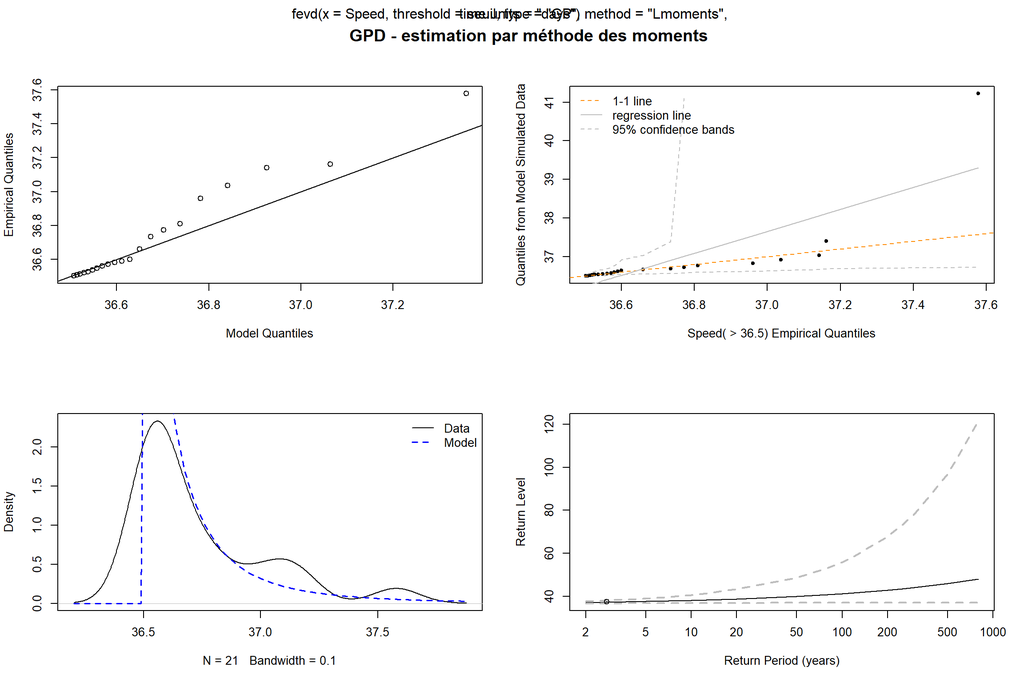

```
## fevd(x = Speed, threshold = seuil, type = "GP", method = "Lmoments",
##     time.units = "days")
##
## [1] "Parametric Bootstrap"
## 502  iterations
##
## [1] "100-year level: 41.254"
##
## [1] "95% Confidence Interval: (37.1027, 58.2974)"
```

```
## fevd(x = Speed, threshold = seuil, type = "GP", method = "Lmoments",
##     time.units = "days")
##
## [1] "Parametric Bootstrap"
## 502  iterations
##
## [1] "1000-year level: 49.194"
##
## [1] "95% Confidence Interval: (37.2193, 145.9715)"
```

La valeur estimée de gamma (shape) est positive (0.41> 0). Fréchet ressort encore comme le domaine d’appartenance de la distribution des extrêmes.  
Les graphiques ne donnent pas non plus ici de bons resultats d’ajustement.

**Niveaux de retour**

Le niveau de retour à 100 ans est ici de 41.25 km/h, (8.73 secondes au 100m) et le niveau de retour à 1000 ans de 49.19 km/h, (7.32 secondes au 100m).

# Conclusion

[output not shown]

Les valeurs extrêmes des performances de course au 100m appartiennent au domaine de **Fréchet**, ainsi que le confirme chaque méthode testée. Les graphiques ne donnent cependant pas des ajustements de qualité similaires: la méthode GEV avec estimation des paramètres par la méthode des moments présente les meilleures adéquations des quantiles empiriques/ théoriques/ simulés .

La méthode retenue est donc :

**Distribution des valeurs extrêmes (GEV) / Moments**

**- Domaine = Fréchet**  
**- Estimation position = 35.24**  
**- Estimation echelle = 0.32**  
**- Estimation forme = 0.08**  
**- Niveau de retour à 100 ans = 9.73s/100m**  
Ce niveau est supérieur au temps minimum observé dans la série : 9,58s, record du monde au 100m détenu par Usain Bolt couru le 16 août 2009 en finale des championnats du monde. Donc, on prévoit que Usain Bolt ne sera pas détroné dans les 100 ans à venir!

**- Niveau de retour à 1000 ans = 9.43s/100m**